# Análisis Exploratorio de Datos

12/3/2017

### Perfil demográfico de los becarios

Análisis de la distribución de becarios por edad, sexo, sector laboral, ciudad/departamento origen y ciudad/departamento residencia.

#### Preprocesamiento:

- Para EDAD: el histograma se limita en base a los valores min,max de la columna edad, a fin de obtener un mejor grafico.
- Para SECTOR LABORAL: creamos nueva columna “sectortrabajofuncionario”. Con grep() obtenemos con valor privado si es que el valor de funcionariopublicoinstitucion es NO. Por otra parte, con grep() y el atributo ‘invert’ obtenemos aquellos registros que no hacen match con la condicion puesta. Es decir, los valores de funcionariopublicoinstitucion distintos a NO se consideran “publico”.
- Observacion: no se considero limpiar valores de ciudades y departamentos: valores que no eran ciudades, valores que no eran departamentos.

#### Cantidad de registros

- 762, excepto en el analisis de becarios por departameto de residencia: 761.

#### Tecnicas utilizadas:

- Edad: hist() [Histograma], boxplot() y summary().
- Sexo: table(). Contabilizamos la cantidad de registros por categoria (feminino/masculino)
- Sector laboral: table(). Contabilizamos la cantidad de registros por categoria (publico/privada)
- Ciudad y departamento de origen: barplot(). Para limitar el grafico de ciudad, utilizamos head() de 20 elementos.
- Ciudad y departamento de residencia: barplot(). Para limitar el grafico de ciudad, utilizamos head() de 20 elementos.

```r
paste("Cantidad de registros (n=",nrow(becal_completo),")")
```

```
## [1] "Cantidad de registros (n= 762 )"
```

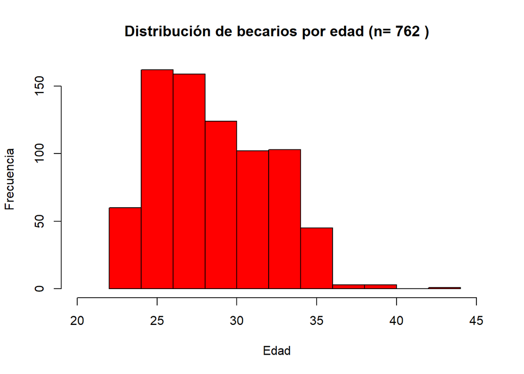

```r
# Edad
hist(becal_completo$edad, main=paste("Distribución de becarios por edad (n=",nrow(becal_completo),")"),  ylab="Frecuencia", xlab="Edad", col = "red", xlim = c(20, 45)) #limitamos esto en base a los valores min,max de la columna edad
```

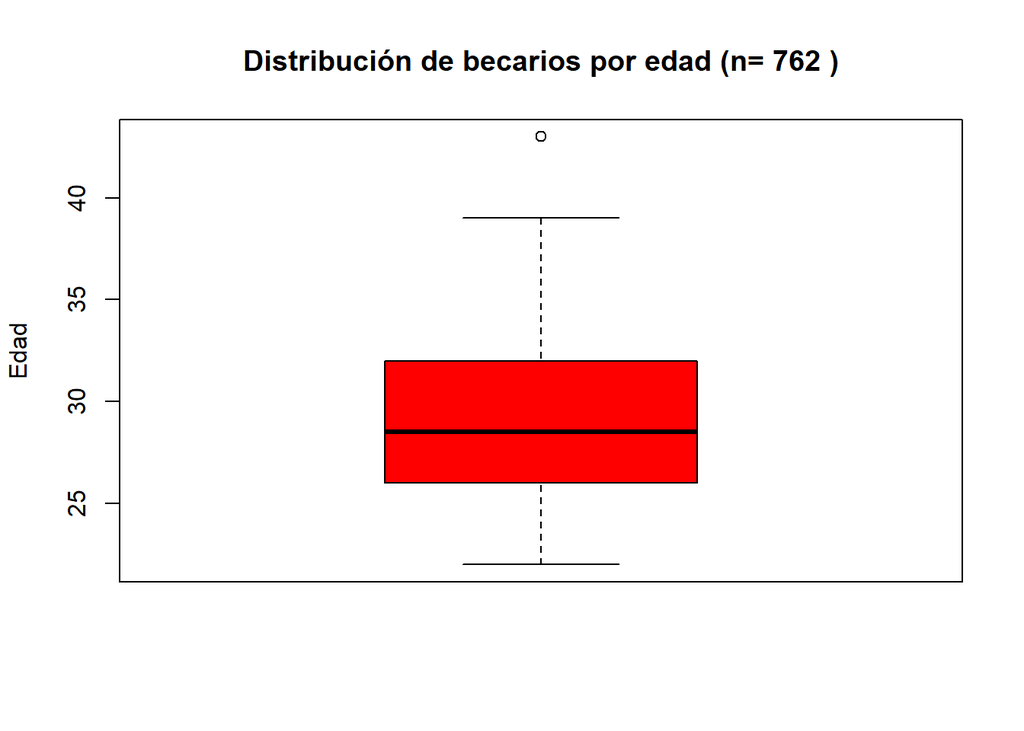

```r
boxplot(becal_completo$edad, col='red', main=paste("Distribución de becarios por edad (n=",nrow(becal_completo),")"), ylab='Edad')
```

```r
summary(becal_completo$edad) #summary
```

```
##    Min. 1st Qu.  Median    Mean 3rd Qu.    Max.
##   22.00   26.00   28.50   28.99   32.00   43.00
```

```r
# Sexo
paste("Cantidad de registros (n=",nrow(becal_completo),")")
```

```
## [1] "Cantidad de registros (n= 762 )"
```

```r
table(becal_completo$sexo) #table() para variables categoricas
```

```
##
##  Femenino Masculino
##       468       294
```

```r
# Sector laboral
paste("Cantidad de registros (n=",nrow(becal_completo),")")
```

```
## [1] "Cantidad de registros (n= 762 )"
```

```r
becal_completo$funcionariopublicoinstitucion = str_trim(becal_completo$funcionariopublicoinstitucion)#quitamos espacios en blanco
becal_completo[grep('NO',becal_completo$funcionariopublicoinstitucion),'sectortrabajofuncionario'] = 'privado' #creamos nueva columna "sectortrabajofuncionario" con valor privado si es que el valor de funcionariopublicoinstitucion es NO
becal_completo[grep('NO',becal_completo$funcionariopublicoinstitucion, invert = TRUE),'sectortrabajofuncionario'] = 'publico' #con invert traemos aquellos registros que no hacen match con la condicion puesta. Los valores de funcionariopublicoinstitucion distintos a NO se consideran "publico"
table(becal_completo$sectortrabajofuncionario) #para variables categoricas
```

```
##
## privado publico
##     495     267
```

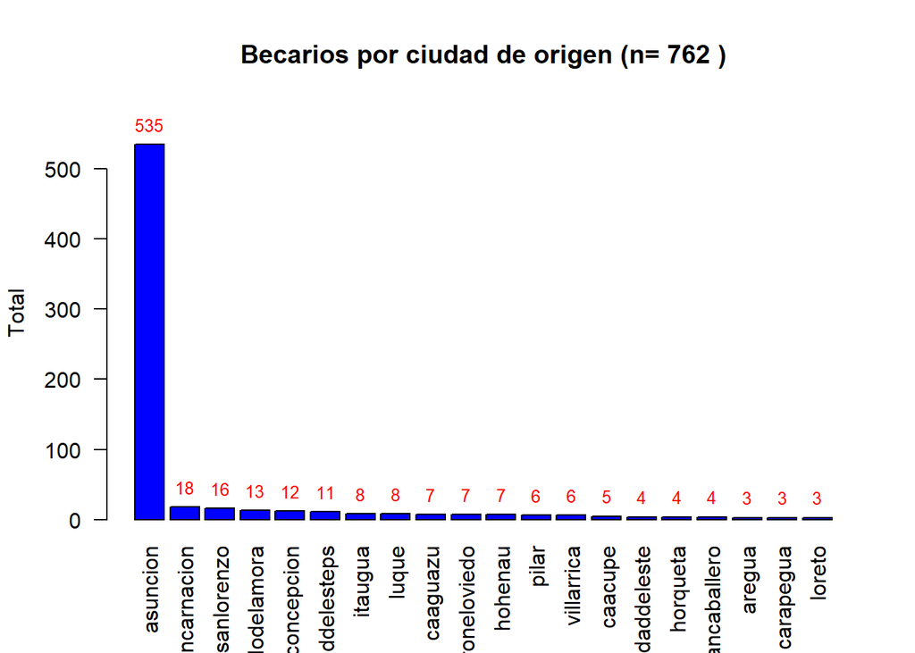

```r
#Ciudad de origen
becal_completo$ciudaddeorigen = limpiar_nombres(becal_completo$ciudaddeorigen)
dis_categoriauni = table(droplevels(as.factor(becal_completo$ciudaddeorigen)))
categoria_ordenadas = head(sort(dis_categoriauni, decreasing = T), 20)  # ordena las categorias de mayor a menor. Solo se muestran los primeros 20 valores
xx = barplot(categoria_ordenadas, ylim = c(0, 1.1* max(categoria_ordenadas)), width = 0.85, main=paste("Becarios por ciudad de origen (n=", nrow(becal_completo),")"), ylab="Total",  col="blue", las = 2, angle = 45)
text(x = xx, y = categoria_ordenadas, label = categoria_ordenadas, pos = 3, cex = 0.8, col = "red") ## Add text at top of bars
```

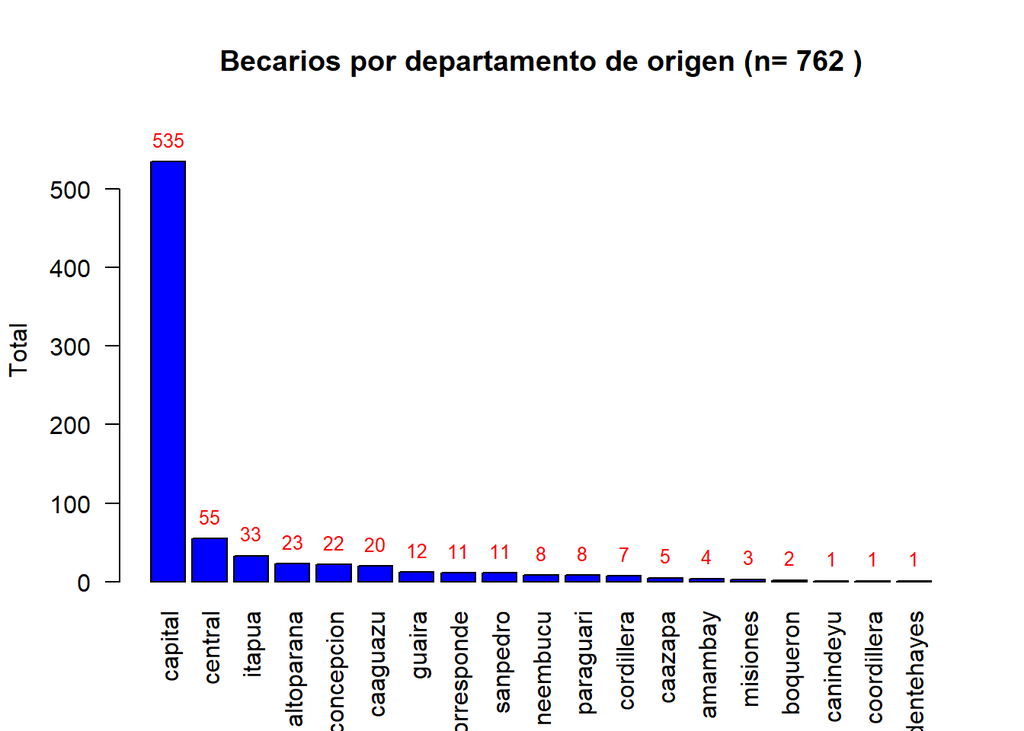

```r
#Departamento de origen
becal_completo$departamentodeorigen = limpiar_nombres(becal_completo$departamentodeorigen)

becal_departamento_sin_na = subset(becal_completo, becal_completo$departamentodeorigen != 'no corresponde' & becal_completo$departamentodeorigen != 'no aplica' & becal_completo$departamentodeorigen != 'sin dato' & becal_completo$departamentodeorigen != '' ) # elimino los valores ausentes

dis_categoriauni = table(droplevels(as.factor(becal_departamento_sin_na$departamentodeorigen)))
categoria_ordenadas = sort(dis_categoriauni, decreasing = T)  # ordena las categorias de mayor a menor. Solo se muestran los primeros 20 valores
xx = barplot(categoria_ordenadas, ylim = c(0, 1.1* max(categoria_ordenadas)), width = 0.85, main=paste("Becarios por departamento de origen (n=", nrow(becal_departamento_sin_na),")"), ylab="Total",  col="blue", las = 2, angle = 45)
text(x = xx, y = categoria_ordenadas, label = categoria_ordenadas, pos = 3, cex = 0.8, col = "red") ## Add text at top of bars
```

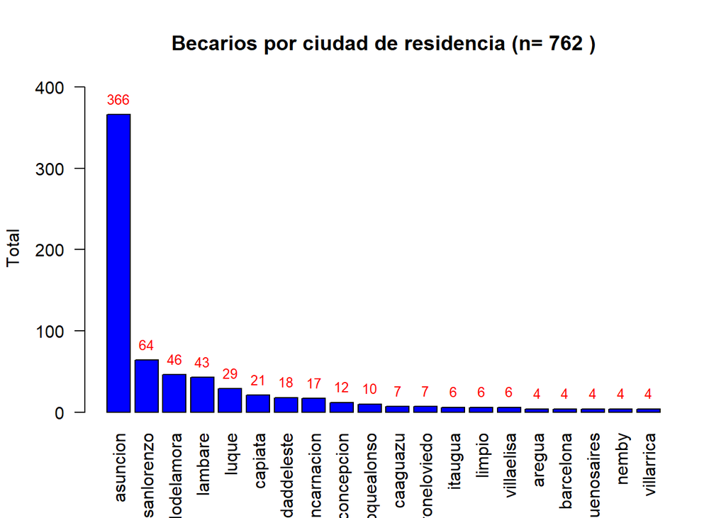

```r
#Ciudad de residencia
becal_completo$ciudadderesidencia = limpiar_nombres(becal_completo$ciudadderesidencia)
dis_categoriauni = table(droplevels(as.factor(becal_completo$ciudadderesidencia)))
categoria_ordenadas = head(sort(dis_categoriauni, decreasing = T), 20)  # ordena las categorias de mayor a menor. Solo se muestran los primeros 20 valores
xx = barplot(categoria_ordenadas, ylim = c(0, 1.1* max(categoria_ordenadas)), width = 0.85, main=paste("Becarios por ciudad de residencia (n=", nrow(becal_completo),")"), ylab="Total",  col="blue", las = 2,  angle = 45)
text(x = xx, y = categoria_ordenadas, label = categoria_ordenadas, pos = 3, cex = 0.8, col = "red") ## Add text at top of bars
```

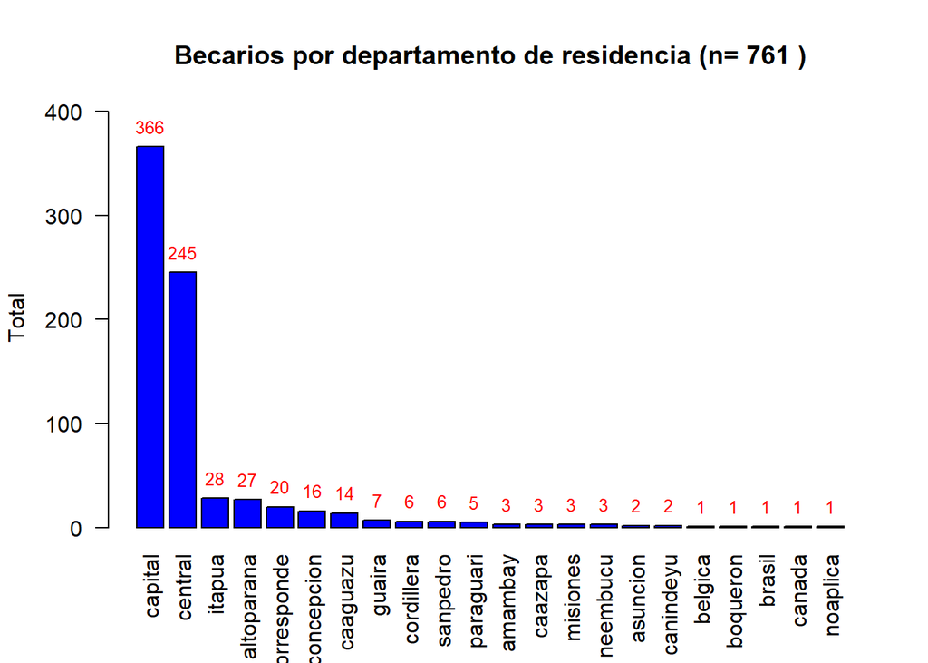

```r
#Departamento de residencia
becal_completo$departamentoderesidencia = limpiar_nombres(becal_completo$departamentoderesidencia)

becal_departamento_sin_na = subset(becal_completo, becal_completo$departamentoderesidencia != 'no corresponde' & becal_completo$departamentoderesidencia != 'no aplica' & becal_completo$departamentoderesidencia != 'sin dato' & becal_completo$departamentoderesidencia != '' ) # elimino los valores ausentes

dis_categoriauni = table(droplevels(as.factor(becal_departamento_sin_na$departamentoderesidencia)))
categoria_ordenadas = sort(dis_categoriauni, decreasing = T)  # ordena las categorias de mayor a menor. Solo se muestran los primeros 20 valores

xx = barplot(categoria_ordenadas, ylim = c(0, 1.1* max(categoria_ordenadas)), width = 0.85, main=paste("Becarios por departamento de residencia (n=", nrow(becal_departamento_sin_na),")"), ylab="Total",  col="blue", las = 2, angle = 45)
text(x = xx, y = categoria_ordenadas, label = categoria_ordenadas, pos = 3, cex = 0.8, col = "red") ## Add text at top of bars
```

### Tipo de estudios, áreas de la ciencia, y disciplinas

Análisis de la distribución de becarios por tipo de beca y disciplina.

#### Tecnica utilizada

- Por tipo de beca: barplot()
- Por disciplina: barplot()

#### Consideraciones:

- Para el analisis del tipo de beca, se consideraron analizar las columnas ‘tipodebecasegunprogramaaprobado’ y ‘tipoestudio’.
- Para el analisis de las disciplinas, fue necesario utilizar la funcion head(), limitando el grafico a 20 elementos.

#### Cantidad de registros:

```r
paste("Cantidad de registros (n=", nrow(becal_completo),")")
```

```
## [1] "Cantidad de registros (n= 762 )"
```

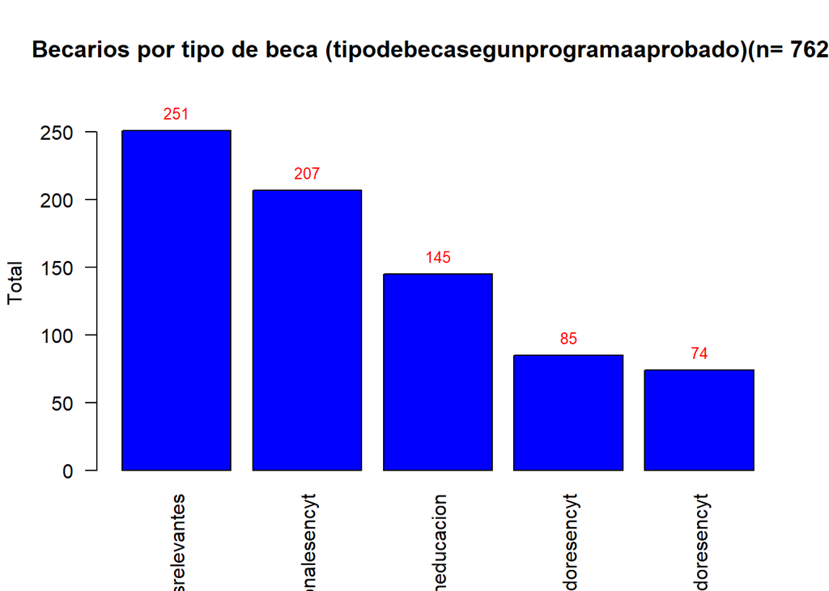

```r
#tipo de beca (tipodebecasegunprogramaaprobado)
becal_completo$tipodebecasegunprogramaaprobado = limpiar_nombres(becal_completo$tipodebecasegunprogramaaprobado)
dis_categoriauni = table(droplevels(as.factor(becal_completo$tipodebecasegunprogramaaprobado)))
categoria_ordenadas = sort(dis_categoriauni, decreasing = T)  # ordena las categorias de mayor a menor. Solo se muestran los primeros 20 valores
xx = barplot(categoria_ordenadas, ylim = c(0, 1.1* max(categoria_ordenadas)), width = 0.85, main=paste("Becarios por tipo de beca (tipodebecasegunprogramaaprobado)(n=", nrow(becal_completo),")"), ylab="Total",  col="blue", las = 2, angle = 45)
text(x = xx, y = categoria_ordenadas, label = categoria_ordenadas, pos = 3, cex = 0.8, col = "red") ## Add text at top of bars
```

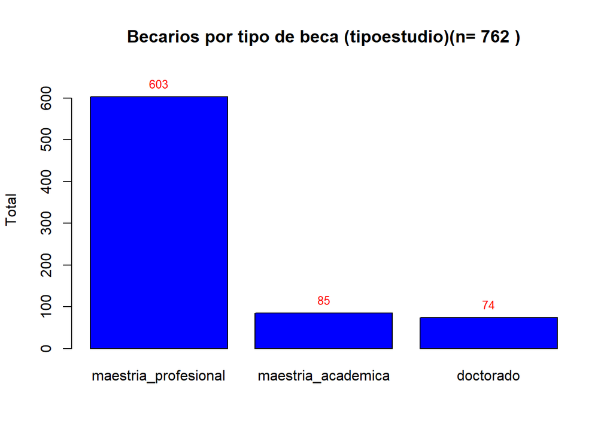

```r
#tipo de beca (tipoestudio)
dis_categoriauni = table(droplevels(as.factor(becal_completo$tipoestudio)))
categoria_ordenadas = sort(dis_categoriauni, decreasing = T)  # ordena las categorias de mayor a menor. Solo se muestran los primeros 20 valores
xx = barplot(categoria_ordenadas, ylim = c(0, 1.1* max(categoria_ordenadas)), width = 0.85, main=paste("Becarios por tipo de beca (tipoestudio)(n=", nrow(becal_completo),")"), ylab="Total",  col="blue", angle = 45)
text(x = xx, y = categoria_ordenadas, label = categoria_ordenadas, pos = 3, cex = 0.8, col = "red") ## Add text at top of bars
```

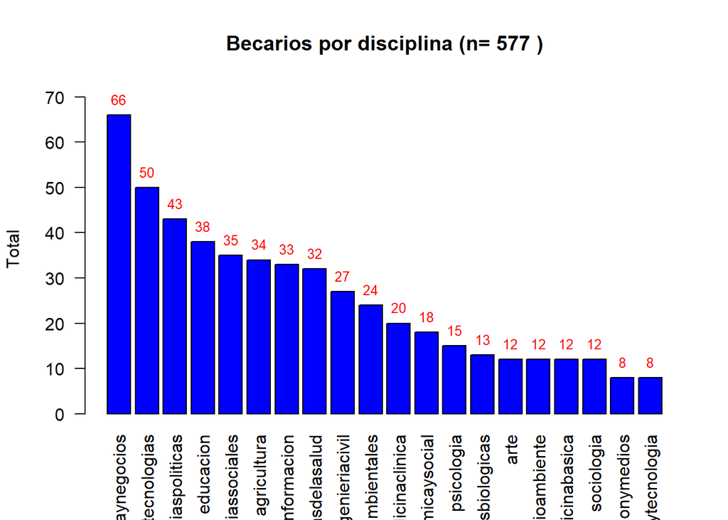

```r
#disciplina
becal_completo$disciplina = limpiar_nombres(becal_completo$disciplina)
becal_disciplina_sin_na = subset(becal_completo, becal_completo$disciplina != '')
dis_categoriauni = table(droplevels(as.factor(becal_disciplina_sin_na$disciplina)))
categoria_ordenadas = head(sort(dis_categoriauni, decreasing = T),20)  # ordena las categorias de mayor a menor. Solo se muestran los primeros 20 valores
xx = barplot(categoria_ordenadas, ylim = c(0, 1.1* max(categoria_ordenadas)), width = 0.85, main=paste("Becarios por disciplina (n=", nrow(becal_disciplina_sin_na),")"), ylab="Total",  col="blue", las = 2)
text(x = xx, y = categoria_ordenadas, label = categoria_ordenadas, pos = 3, cex = 0.8, col = "red") ## Add text at top of bars
```

### Duración de estudios

Análisis para calcular el promedio, la mediana, el mínimo, máximo, desviación estándar, y los cuantiles (0.25, 0.75) del tiempo de duración de los estudios.

#### Preprocesamiento

- Limpiamos los meses con duracion 0 y los NA (columna ‘mesesdeduraciondeestudios’).

#### Tecnica utilizada

- Para encontrar el promedio, la mediana, el mínimo y máximo, utilizamos la funcion summary().
- Para la desviación estándar utilizamos la funcion sd().
- Para los cuantiles, usamos quantile().

```r
#Preprocesamiento
becal_completo$mesesdeduraciondeestudios = as.numeric(becal_completo$mesesdeduraciondeestudios)
becal_meses_duracion_limpio = subset(becal_completo, becal_completo$mesesdeduraciondeestudios > 0) #limpiamos los meses con duracion 0 y los NA

paste("Cantidad de registros (n=", nrow(becal_meses_duracion_limpio),")")
```

```
## [1] "Cantidad de registros (n= 759 )"
```

```r
summary(becal_meses_duracion_limpio$mesesdeduraciondeestudios)
```

```
##    Min. 1st Qu.  Median    Mean 3rd Qu.    Max.
##    9.00   13.00   16.00   19.29   24.00   53.00
```

```r
sd(becal_meses_duracion_limpio$mesesdeduraciondeestudios)
```

```
## [1] 9.132723
```

```r
quantile(becal_meses_duracion_limpio$mesesdeduraciondeestudios, probs = c(0.25, 0.75, 1))
```

```
##  25%  75% 100%
##   13   24   53
```

### Completitud de estudios

Análisis para calcular los cuantiles (25%, 50%, 75%, 100%) de completitud de los estudios.

#### Preprocesamiento:

- Limpiamos los meses con duracion 0 y los NA (columna ‘mesesdeduraciondeestudios’).
- Eliminamos registros con formato de fecha de inicio de cobertura incorrecto o incompleto (columna ‘iniciocoberturadebeca’).

#### Tecnica utilizada:

- Basandonos en la funcion completitud() de utils.R, generamos la funcion completitud_for(). Ambas funciones trabajan de la misma forma, solo varia el loop (con completitud() y sapply() o apply(), generaba error de length.out de duracion).
- Para analizar los cuantiles utilizamos quantile().

```r
#preprocesamiento
becal_completo$mesesdeduraciondeestudios = as.numeric(becal_completo$mesesdeduraciondeestudios)
becal_meses_duracion_limpio = subset(becal_completo, becal_completo$mesesdeduraciondeestudios > 0) #limpiamos los meses con duracion 0 y los NA
becal_meses_duracion_limpio = becal_meses_duracion_limpio[grep('-',becal_meses_duracion_limpio$iniciocoberturadebeca, invert = TRUE),] #eliminamos aquellos registros con iniciocobertura con formato <fecha>-<fecha>-<fecha>
becal_meses_duracion_limpio = becal_meses_duracion_limpio[grep('Y',becal_meses_duracion_limpio$iniciocoberturadebeca, invert = TRUE),] #eliminamos aquellos registros con iniciocobertura con formato <fecha> Y <fecha>
becal_meses_duracion_limpio = becal_meses_duracion_limpio[grep('al',becal_meses_duracion_limpio$iniciocoberturadebeca, invert = TRUE),] #eliminamos aquellos registros con iniciocobertura con formato <fecha> al <fecha>
becal_meses_duracion_limpio = becal_meses_duracion_limpio[grep('010/16',becal_meses_duracion_limpio$iniciocoberturadebeca, invert = TRUE),] #eliminamos el caso de uno de los registros con fecha 1/010/16, donde el formato del anho no corresponde

paste("Cantidad de registros (n=", nrow(becal_meses_duracion_limpio),")")
```

```
## [1] "Cantidad de registros (n= 738 )"
```

```r
##### Version de completitud de utils.R con el loop for. Esto soluciona un error con el sapply
completitud_for = function(x) {
  list <- integer(0)
  for(i in seq_len(nrow(x))){

    inicio = x[i,'iniciocoberturadebeca']
    duracion = x[i,'mesesdeduraciondeestudios']

    hoy = Sys.Date()
    duracion = as.numeric(duracion)
    inicio = as.Date(strptime(inicio, "%m/%d/%Y"))
    aux_fin = seq(inicio, by='months',length.out=duracion)
    fin = aux_fin[length(aux_fin)]
    if (hoy >= fin) {
      list <- c(list,100) #generamos nueva lista con los valores del porcentaje almacenados y adjuntamos el valor determinado
    } else {
      meses_completados = length(seq(inicio, hoy, by='months'))-1
      porcentaje_faltante = round((meses_completados/duracion)*100,0)
      list <- c(list,porcentaje_faltante) #generamos nueva lista con los valores del porcentaje almacenados y adjuntamos el valor determinado
    }
  }

  return(list)
}

#####
x = completitud_for(becal_meses_duracion_limpio)
summary(x)
```

```
##    Min. 1st Qu.  Median    Mean 3rd Qu.    Max.
##    5.00   71.00  100.00   81.87  100.00  100.00
```

```r
quantile(x, probs = c(0.25, 0.5, 0.75, 1))
```

```
##  25%  50%  75% 100%
##   71  100  100  100
```

### Países, ciudades, y universidades de destino

Análisis de la distribución de becas por país, ciudad, y universidad de destino;

#### Tecnica utilizada:

- Tanto para analizar la distribucion de becas por pais, ciudad y universidad destino, utilizamos barplot().

#### Consideraciones:

- Para limitar los valores del grafico de ciudad y universidad destino, utilizamos head() de 20 elementos.

```r
paste("Cantidad de registros (n=", nrow(becal_completo),")")
```

```
## [1] "Cantidad de registros (n= 762 )"
```

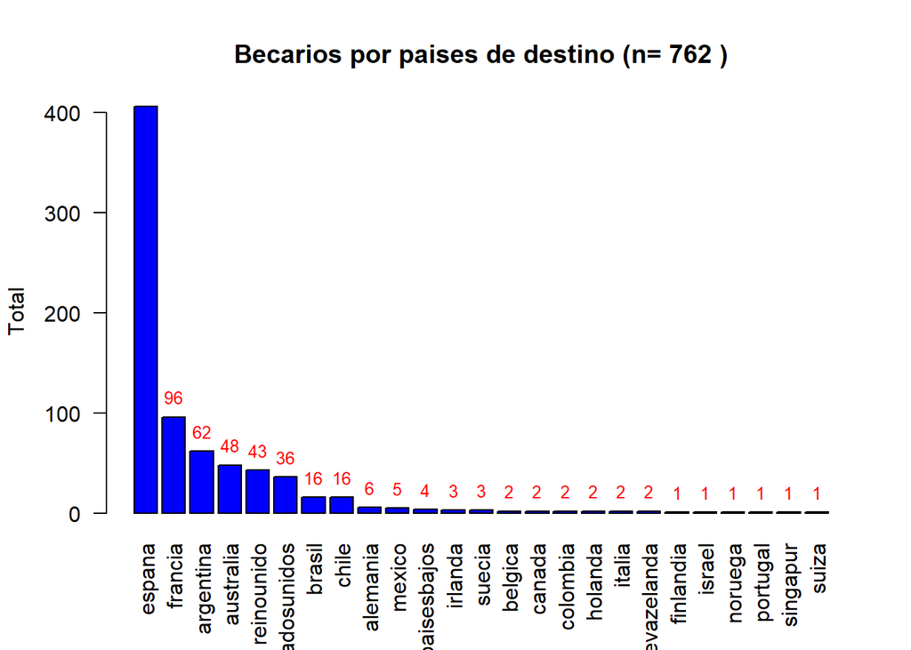

```r
#Pais de destino
becal_completo$paisdedestino = limpiar_nombres(becal_completo$paisdedestino)
dis_pais_destino = table(droplevels(as.factor(becal_completo$paisdedestino)))
categoria_ordenadas = sort(dis_pais_destino, decreasing = T)  # ordena las categorias de mayor a menor. Solo se muestran los primeros 20 valores
xx = barplot(categoria_ordenadas, main=paste("Becarios por paises de destino (n=",nrow(becal_completo),")"), ylab="Total", col="blue", las = 2)
text(x = xx, y = categoria_ordenadas, label = categoria_ordenadas, pos = 3, cex = 0.8, col = "red") ## Add text at top of bars
```

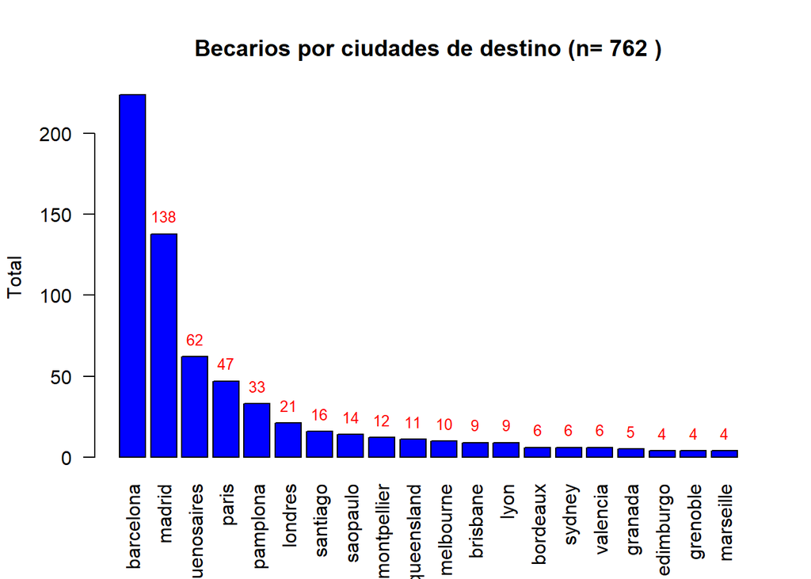

```r
#Ciudades de destino
becal_completo$ciudaddedestinoenespanol = limpiar_nombres(becal_completo$ciudaddedestinoenespanol)
dis_pais_destino = table(droplevels(as.factor(becal_completo$ciudaddedestinoenespanol)))
categoria_ordenadas = head(sort(dis_pais_destino, decreasing = T), 20)  # ordena las categorias de mayor a menor. Solo se muestran los primeros 20 valores
xx = barplot(categoria_ordenadas, main=paste("Becarios por ciudades de destino (n=",nrow(becal_completo),")"), ylab="Total", col="blue", las = 2)
text(x = xx, y = categoria_ordenadas, label = categoria_ordenadas, pos = 3, cex = 0.8, col = "red") ## Add text at top of bars
```

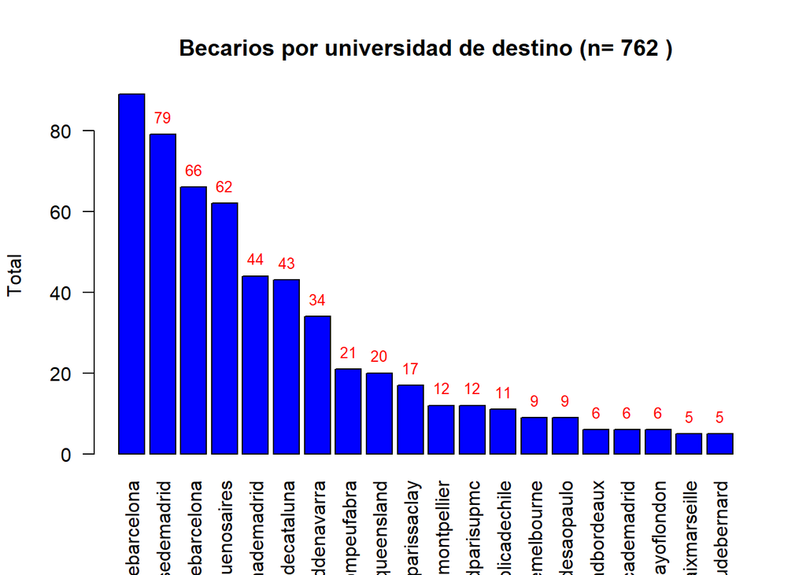

```r
#Universidad de destino
becal_completo$universidaddedestino = limpiar_nombres(becal_completo$universidaddedestino)
dis_univ_destino = table(droplevels(as.factor(becal_completo$universidaddedestino)))
categoria_ordenadas = head(sort(dis_univ_destino, decreasing = T), 20)  # ordena las categorias de mayor a menor. Solo se muestran los primeros 20 valores
xx= barplot(categoria_ordenadas, main=paste("Becarios por universidad de destino (n=",nrow(becal_completo),")"), ylab="Total", col="blue", las = 2)

text(x = xx, y = categoria_ordenadas, label = categoria_ordenadas, pos = 3, cex = 0.8, col = "red") ## Add text at top of bars
```

#### Resultados

- Los paises destino mas elegidos por los becarios son España, Francia, Argentina, Australia y Reino Unido.
- Las ciudades destino mas elegidas son Barcelona, MAdrid y Buenos Aires.
- Las universidades mas elegidas para realizar la beca son: Universidad de Barcelona, Universidad Complutense de Madrid, Universidad Autonoma de Barcelona, Universidad de Buenos Aires y Universidad Autonoma de Madrid.

### Becarios por rango de ranking de universidad de destino

Análisis que permita investigar la distribución de becarios por rango de ranking de universidad de destino (top 10, top 50, top 100, top 150, top 200, mayor a 200)

#### Preprocesamiento:

- Eliminamos los registros “sin dato” de la columna ‘categoriauni’

#### Tecnica utlizada:

barplot()

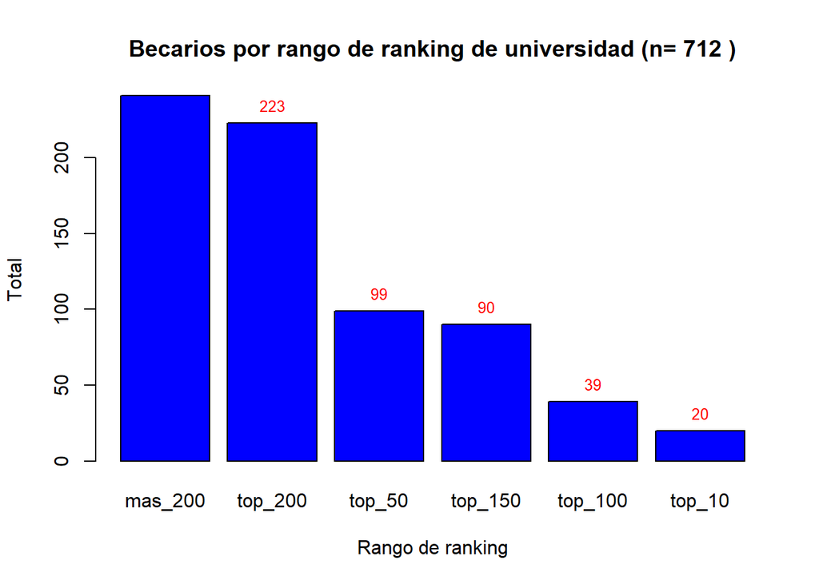

```r
becal_limpio = subset(becal_completo, categoriauni != "sin dato") # elimina los registros "sin dato"
dis_categoriauni = table(droplevels(as.factor(becal_limpio$categoriauni)))
categoria_ordenadas = sort(dis_categoriauni, decreasing = T)  # ordena las categorias de mayor a menor. Solo se muestran los primeros 20 valores
xx = barplot(categoria_ordenadas, main=paste("Becarios por rango de ranking de universidad (n=", nrow(becal_limpio),")"), ylab="Total", xlab="Rango de ranking", col="blue")
text(x = xx, y = categoria_ordenadas, label = categoria_ordenadas, pos = 3, cex = 0.8, col = "red") ## Add text at top of bars
```

#### Resultados

- La opcion mas elegida por becarios corresponde a universidades con ranking mayor a 200. Solo 20 becarios pertenecen a universidades dentro del top 10.

### Becas

Análisis que calcular el promedio, la mediana, el mínimo, máximo, y desviación estándar de los montos de beca

#### Preprocesamiento:

- Eliminamos NA y valores 0 de la columna ‘totalgralusd’

#### Tecnicas utilizadas:

- Para encontrar el promedio, la mediana, el mínimo, máximo, utilizamos summary().
- Para encontrar la desviacion estandar, sd().

```r
#preprocesamiento
becal_total_limpio = subset(becal_completo, becal_completo$totalgralusd > 0) ##eliminamos NA y valores 0

summary(becal_total_limpio$totalgralusd)
```

```
##    Min. 1st Qu.  Median    Mean 3rd Qu.    Max.
##    8600   31394   41925   49292   61721  180000
```

```r
sd(becal_total_limpio$totalgralusd)
```

```
## [1] 22728.26
```

#### Resultados

- La cobertura de beca mas cara es de 180000USD. La mas barata es de 8600USD. El promedio del costo de cobertura es de 49292USD.
- La desviacion estandar es de 22728.26

### Porcentaje de cobertura

Análisis que calcular los cuantiles (25%, 50%, 75%, 100%) de cobertura

#### Preprocesamiento:

- Eliminamos NA y valores 0 de la columna ‘totalgralusd’.

#### Tecnica utilizada:

- Para cuantiles, la funcion quantile().

```r
#preprocesamiento
becal_total_limpio = subset(becal_completo, becal_completo$totalgralusd > 0) #eliminamos NA y valores 0

quantile(becal_total_limpio$totalgralusd, probs = c(0.25, 0.5, 0.75, 1))
```

```
##    25%    50%    75%   100%
##  31394  41925  61721 180000
```

#### Resultados

- 0.25-> 31394; 0.5->41925; 0.75->61721; 1->180000

### Top-10 montos de cobertura

Análisis que calcular el top-10 de montos de coberturas y el tipo de estudio a que corresponden.

#### Preprocesamiento:

- Eliminamos NA y valores 0 de la columna ‘totalgralusd’.
- Encontramos los distintos montos de cobertura en la columna ‘totalgralusd’, utilizando duplicated().
- Ordenamos los montos de manera descendente, y con head() tomamos los 10 primeros montos.

#### Tecnica utilizada:

- Analisis de tabla (data frame)

```r
becal_total_limpio = subset(becal_completo, becal_completo$totalgralusd > 0) #eliminamos NA y valores 0
becal_total_unique_values = becal_total_limpio[!duplicated(becal_total_limpio$totalgralusd),]#solo tomamos valores unicos de los montos, de manera a agarrar el top de los montos

categoria_ordenada = becal_total_unique_values[order(-becal_total_unique_values$totalgralusd),]#ordenamos el dataset por monto de cobertura (descendente)

#becarios_cobertura_top_10 =  table(droplevels(as.factor(categoria_ordenada$tipoestudio)), categoria_ordenada$totalgralusd)
becarios_cobertura_top_10 = head(categoria_ordenada[,c('tipoestudio','totalgralusd')],10)#tomamos los primeros diez valores

becarios_cobertura_top_10 #TOP-10 Montos de cobertura
```

```
##              tipoestudio totalgralusd
## 83             doctorado       180000
## 265            doctorado       169768
## 810            doctorado       157568
## 485            doctorado       146908
## 759 maestria_profesional       146132
## 451            doctorado       109292
## 238   maestria_academica       108740
## 634            doctorado       108130
## 729            doctorado       107927
## 222            doctorado       100100
```

#### Preprocesamiento:

- Eliminamos NA y valores 0 de la columna ‘totalgralusd’

#### Tecnica utilizada:

- PAra analizar la correlacion, utilizamos la funcion cor().

```r
becal_total_limpio = subset(becal_completo, becal_completo$totalgralusd > 0) #eliminamos NA y valores 0
cor(as.numeric(becal_total_limpio$mesesdeduraciondeestudios), becal_total_limpio$totalgralusd) #correlacion.
```

```
## [1] 0.6509168
```